# Dissertation Analysis: Frustration - Strategy

Jamiahus Walton

2019-06-17

# Motivation

In a previous analysis, I found that it is possible that the Target level may explain some of the vairnece in the frustration levels of individuals when you consider the stratgey used by the team. I want to examine this possiblity.

# Q: Is there exciting variation among the *Frustration* metric that will help me understand the influence of the feedback condition?

## Team

There is no team level analysis because I have not developed a team levels analysis.

## Individual

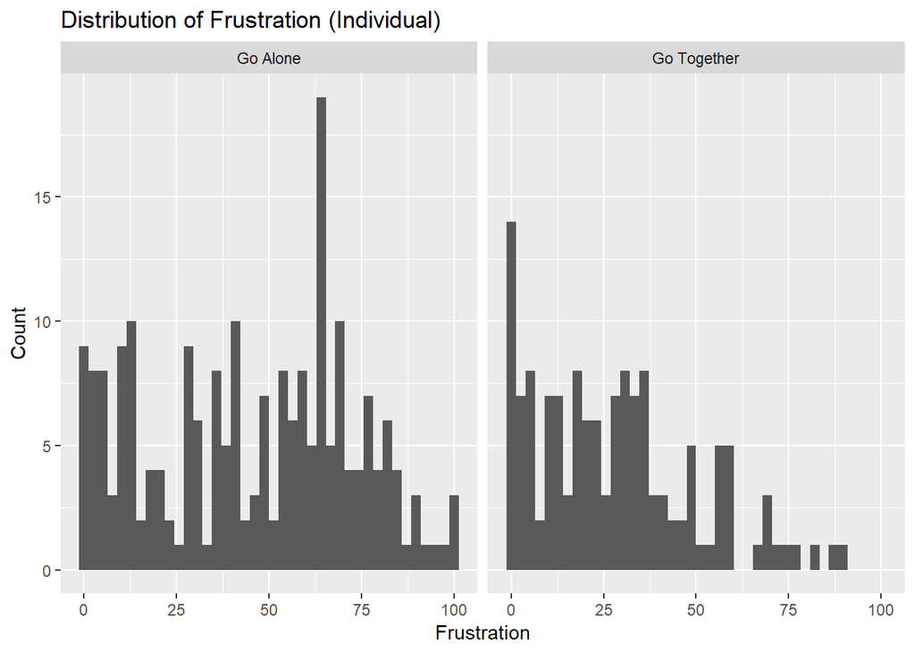

```r
y_label_ind <- "Count"
x_label_ind <- params$dependent_response_name_WithSpace
title_response_ind <- paste("Distribution of", params$dependent_response_name_WithSpace, "(Individual)")
plot_name <- paste("Histogram_", params$dependent_response_name_NoSpace, "_Ind.png", sep = "")
setwd(figure_directory)

plot_data_ind <- ind_data %>%
  select(params$dependent_response_ind, params$dependent_response_DominateStrategy, Target)

ggplot(data = plot_data_ind) +
  geom_histogram(aes_string(x = params$dependent_response_ind), bins = 40) +
  facet_grid(. ~ .data[[params$dependent_response_DominateStrategy]]) +
  labs(title = title_response_ind, x = x_label_ind, y = y_label_ind) +
  ggsave(filename = plot_name)
```

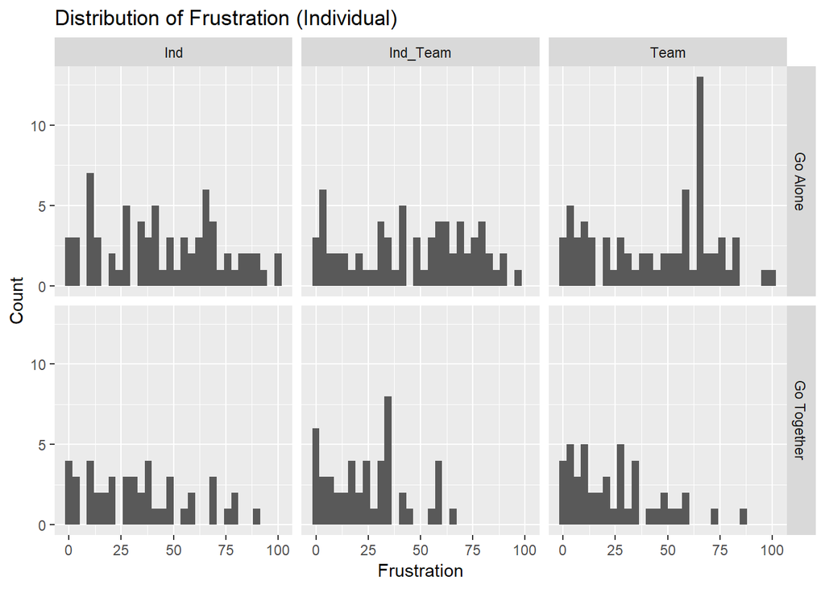

```r
y_label_ind <- "Count"
x_label_ind <- params$dependent_response_name_WithSpace
title_response_ind <- paste("Distribution of", params$dependent_response_name_WithSpace, "(Individual)")
plot_name <- paste("Histogram_", params$dependent_response_name_NoSpace, "_ByTarget_Ind.png", sep = "")
setwd(figure_directory)

plot_data_ind <- ind_data %>%
  select(params$dependent_response_ind, params$dependent_response_DominateStrategy, Target)

ggplot(data = plot_data_ind) +
  geom_histogram(aes_string(x = params$dependent_response_ind), bins = 30) +
  facet_grid(.data[[params$dependent_response_DominateStrategy]] ~ Target) +
  labs(title = title_response_ind, x = x_label_ind, y = y_label_ind) +
  ggsave(filename = plot_name)
```

```r
# Information about the N values in each condition
tableData <- ind_data %>%
  group_by(Target, .data[[params$dependent_response_DominateStrategy]]) %>%
  summarise(N = length(.data[[params$dependent_response_ind]]))

tableData %>%
  kable() %>%
  kable_styling()
```

| Target | Dominate.Strategy | N |
| --- | --- | --- |
| Ind | Go Alone | 72 |
| Ind | Go Together | 45 |
| Ind_Team | Go Alone | 69 |
| Ind_Team | Go Together | 48 |
| Team | Go Alone | 72 |
| Team | Go Together | 45 |

Go Alone: There seems to be no difference among the groups. Each group seems to have a wide varience.

Go Together: There seems to be a skew to the left for teams using the Go Together method in the Team and Ind_Team condition.

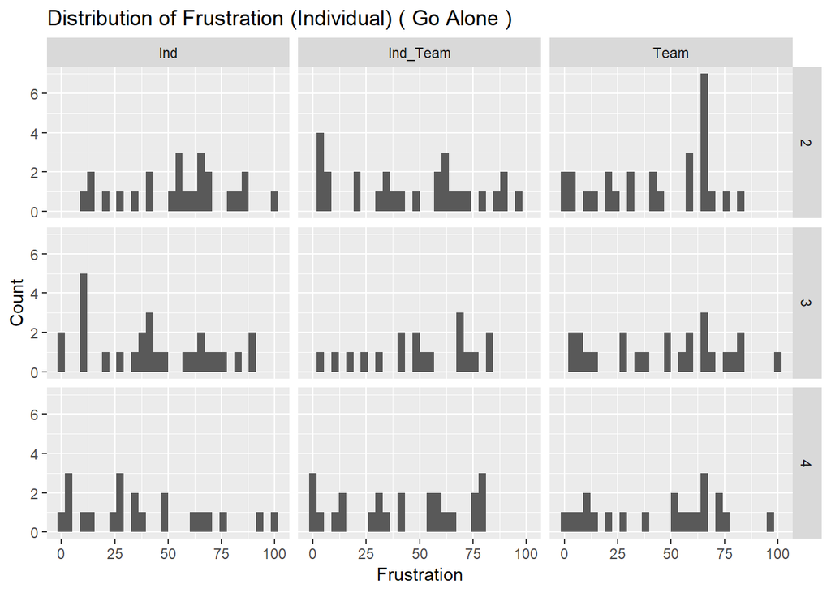

```r
y_label_ind <- "Count"
x_label_ind <- params$dependent_response_name_WithSpace
setwd(figure_directory)

plot_data_ind <- ind_data %>%
  select(params$dependent_response_ind,
         params$dependent_response_DominateStrategy,
         Target,
         SessionOrder)

# Generate data by strategy
GA_plot_data_ind <- plot_data_ind %>%
  filter(.data[[params$dependent_response_DominateStrategy]] == params$Strategy_GA_name_WithSpace)

GT_plot_data_ind <- plot_data_ind %>%
  filter(.data[[params$dependent_response_DominateStrategy]] == params$Strategy_GT_name_WithSpace)

# plot
  # GA
ggplot(data = GA_plot_data_ind) +
  geom_histogram(aes_string(x = params$dependent_response_ind), bins = 30) +
  facet_grid(SessionOrder ~ Target) +
  labs(title = paste("Distribution of", params$dependent_response_name_WithSpace, "(Individual)","(", params$Strategy_GA_name_WithSpace ,")" ), x = x_label_ind, y = y_label_ind) +
  ggsave(filename = paste("Histogram_", params$dependent_response_name_NoSpace, "_ByTarget_BySessionOrder_", params$Strategy_GA_name_NoSpace, "_Ind.png", sep = ""))
```

```r
    # Information about the N values in each condition
GA_tableData <- GA_plot_data_ind %>%
  select(params$dependent_response_ind, Target, SessionOrder) %>%
  group_by(Target, SessionOrder) %>%
  summarise(N = length(.data[[params$dependent_response_ind]]))

GA_tableData %>%
  kable(caption =  paste("Data for ", params$Strategy_GA_name_WithSpace)) %>%
  kable_styling()
```

Data for Go Alone

| Target | SessionOrder | N |
| --- | --- | --- |
| Ind | 2 | 24 |
| Ind | 3 | 27 |
| Ind | 4 | 21 |
| Ind_Team | 2 | 27 |
| Ind_Team | 3 | 18 |
| Ind_Team | 4 | 24 |
| Team | 2 | 27 |
| Team | 3 | 24 |
| Team | 4 | 21 |

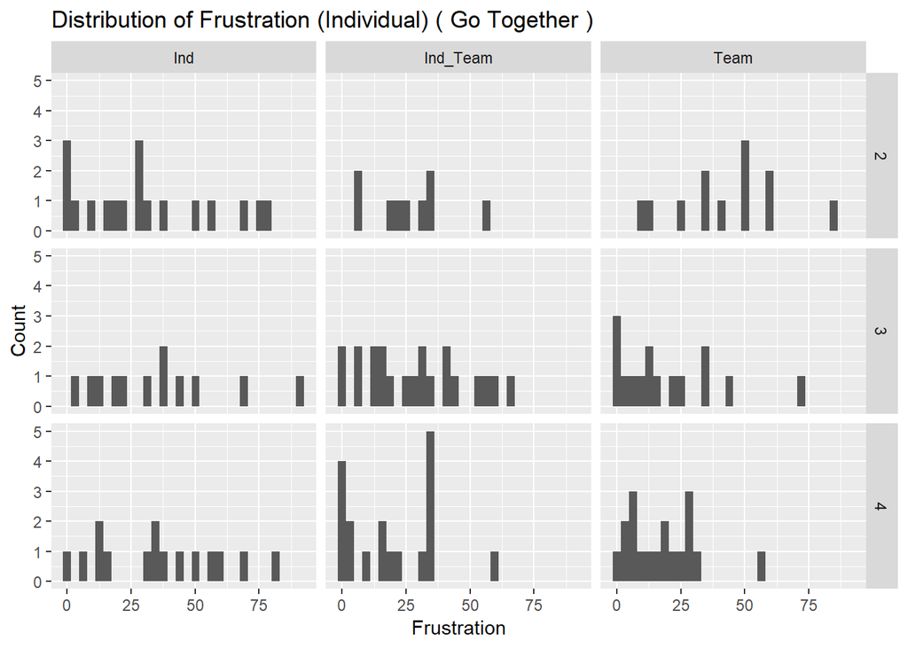

```r
  # GT
ggplot(data = GT_plot_data_ind) +
  geom_histogram(aes_string(x = params$dependent_response_ind), bins = 30) +
  facet_grid(SessionOrder ~ Target) +
  labs(title = paste("Distribution of", params$dependent_response_name_WithSpace, "(Individual)","(", params$Strategy_GT_name_WithSpace ,")" ), x = x_label_ind, y = y_label_ind) +
  ggsave(filename = paste("Histogram_", params$dependent_response_name_NoSpace, "_ByTarget_BySessionOrder_", params$Strategy_GT_name_NoSpace, "_Ind.png", sep = ""))
```

```r
# Information about the N values in each condition
GT_tableData <- GT_plot_data_ind %>%
  select(params$dependent_response_ind, Target, SessionOrder) %>%
  group_by(Target, SessionOrder) %>%
  summarise(N = length(.data[[params$dependent_response_ind]]))

GT_tableData %>%
  kable(caption = paste("Data for ", params$Strategy_GT_name_WithSpace)) %>%
  kable_styling()
```

Data for Go Together

| Target | SessionOrder | N |
| --- | --- | --- |
| Ind | 2 | 18 |
| Ind | 3 | 12 |
| Ind | 4 | 15 |
| Ind_Team | 2 | 9 |
| Ind_Team | 3 | 21 |
| Ind_Team | 4 | 18 |
| Team | 2 | 12 |
| Team | 3 | 15 |
| Team | 4 | 18 |

It looks as though there is variance among the conditions in session 2 but then moving from up (session 2) to down (session 4), the Team condition and the Ind_Team condition skew to the left, while the Ind seems to stay constant (i.e., varied).

## Summary

Overall, it looks like there is something interesting happening in the Go Together strategy at the individual level.

# Q: Is there an interaction between the Target and Session Order for the *Frustration* that is statistically significant?

I am interested in determining if a linear mixed effect model should include the interaction effect between the Target and Session Order variable.

A note on the effect size ($R^2$). This method generates two types of ($R^2$) values called marginal ($R_{m}^2$) and conditional ($R_{c}^2$) effect size. The $R_{m}^2$ calculates how much of the variance is described by the fixed effect variables (feedback condition and session order) while the $R_{c}^2$ calculates how much of the variance is described by both the fixed and random effect variables.

## Full Models Used for Team and Individual

The next two sections below describe the full model for team and individual level analysis. Five models were fitted and then compared. One model was the null model, one model was the full model, and the last three are a subset of the full model.

### Team Full Model

$$y_{ijt} = \mu + \alpha_{i} + \beta_{j} + \alpha_{i} \beta_{j} + \gamma_{t} + \epsilon_{ijt}$$

### Individual Team Full Model

$$y_{ijtp} = \mu + \alpha_{i} + \beta_{j} + \alpha_{i} \beta_{j} + \gamma_{t} + \theta_{p} + \epsilon_{ijtp}$$

## Team

### GA

There is no team level analysis because I have not developed a team levels analysis.

### GT

There is no team level analysis because I have not developed a team levels analysis.

## Individual

### GA

```r
# Data to model
data_modified_ind <- ind_data %>%
  select(params$dependent_response_ind,
         params$dependent_response_DominateStrategy,
         Target,
         SessionOrder,
         Team,
         Player_ID)

# Generate models with variable response
GA_data_focus_ind <- data_modified_ind %>%
  filter(.data[[params$dependent_response_DominateStrategy]] == params$Strategy_GA_name_WithSpace)

model.null <- model_data_Target_Session(df = GA_data_focus_ind, dependent =  params$dependent_response_ind, model.type =  "null", is.team = FALSE, is.robust = FALSE)
model.All <- model_data_Target_Session(df = GA_data_focus_ind, dependent =  params$dependent_response_ind, model.type =  "All", is.team = FALSE, is.robust = FALSE)
model.NoInteraction <- model_data_Target_Session(df = GA_data_focus_ind, dependent =  params$dependent_response_ind, model.type =  "NoInteraction", is.team = FALSE, is.robust = FALSE)
model.NoInteraction.NoTarget <- model_data_Target_Session(df = GA_data_focus_ind, dependent =  params$dependent_response_ind, model.type =  "NoInteraction_NoTarget", is.team = FALSE, is.robust = FALSE)
model.NoInteraction.NoSession <- model_data_Target_Session(df = GA_data_focus_ind, dependent =  params$dependent_response_ind, model.type =  "NoInteraction_NoSession", is.team = FALSE, is.robust = FALSE)

# There is an option to compare all the models with the anova(). However, the function does not compare all models to model.null
anova(model.null,
      model.All) %>%
  kable(caption = "ANOVA: model.null and model.All") %>%
  kable_styling()
```

```
## refitting model(s) with ML (instead of REML)
```

ANOVA: model.null and model.All

|  | Df | AIC | BIC | logLik | deviance | Chisq | Chi Df | Pr(>Chisq) |
| --- | --- | --- | --- | --- | --- | --- | --- | --- |
| model.null | 4 | 1972.570 | 1986.015 | -982.285 | 1964.570 | NA | NA | NA |
| model.All | 12 | 1974.756 | 2015.092 | -975.378 | 1950.756 | 13.81386 | 8 | 0.0867479 |

```r
anova(model.null,
      model.NoInteraction) %>%
  kable(caption = "ANOVA: model.null and model.NoInteraction") %>%
  kable_styling()
```

```
## refitting model(s) with ML (instead of REML)
```

ANOVA: model.null and model.NoInteraction

|  | Df | AIC | BIC | logLik | deviance | Chisq | Chi Df | Pr(>Chisq) |
| --- | --- | --- | --- | --- | --- | --- | --- | --- |
| model.null | 4 | 1972.570 | 1986.015 | -982.2850 | 1964.570 | NA | NA | NA |
| model.NoInteraction | 8 | 1975.617 | 2002.508 | -979.8087 | 1959.617 | 4.952496 | 4 | 0.2922065 |

```r
anova(model.null,
      model.NoInteraction.NoTarget) %>%
  kable(caption = "ANOVA: model.null and model.NoInteraction.NoTarget") %>%
  kable_styling()
```

```
## refitting model(s) with ML (instead of REML)
```

ANOVA: model.null and model.NoInteraction.NoTarget

|  | Df | AIC | BIC | logLik | deviance | Chisq | Chi Df | Pr(>Chisq) |
| --- | --- | --- | --- | --- | --- | --- | --- | --- |
| model.null | 4 | 1972.57 | 1986.015 | -982.2850 | 1964.57 | NA | NA | NA |
| model.NoInteraction.NoTarget | 6 | 1971.72 | 1991.888 | -979.8602 | 1959.72 | 4.849422 | 2 | 0.0885037 |

```r
anova(model.null,
      model.NoInteraction.NoSession) %>%
  kable(caption = "ANOVA: model.null and model.NoInteraction.NoSession") %>%
  kable_styling()
```

```
## refitting model(s) with ML (instead of REML)
```

ANOVA: model.null and model.NoInteraction.NoSession

|  | Df | AIC | BIC | logLik | deviance | Chisq | Chi Df | Pr(>Chisq) |
| --- | --- | --- | --- | --- | --- | --- | --- | --- |
| model.null | 4 | 1972.570 | 1986.015 | -982.2850 | 1964.570 | NA | NA | NA |
| model.NoInteraction.NoSession | 6 | 1976.469 | 1996.637 | -982.2345 | 1964.469 | 0.1009764 | 2 | 0.9507652 |

No model is significantly different from the null model. The modles that are marginally significant are model.All and model.NoInteraction.NoTarget.

[skipping comparing models that are significantly different from the null model because none were significantly different from the null model.]

```r
# Data to model
data_modified_ind <- ind_data %>%
  select(params$dependent_response_ind,
         params$dependent_response_DominateStrategy,
         Target,
         SessionOrder,
         Team,
         Player_ID)

# Generate models with variable response
GA_data_focus_ind <- data_modified_ind %>%
  filter(.data[[params$dependent_response_DominateStrategy]] == params$Strategy_GA_name_WithSpace)

model.null <- model_data_Target_Session(df = GA_data_focus_ind, dependent =  params$dependent_response_ind, model.type =  "null", is.team = FALSE, is.robust = FALSE)
model.All <- model_data_Target_Session(df = GA_data_focus_ind, dependent =  params$dependent_response_ind, model.type =  "All", is.team = FALSE, is.robust = FALSE)
model.NoInteraction <- model_data_Target_Session(df = GA_data_focus_ind, dependent =  params$dependent_response_ind, model.type =  "NoInteraction", is.team = FALSE, is.robust = FALSE)
model.NoInteraction.NoTarget <- model_data_Target_Session(df = GA_data_focus_ind, dependent =  params$dependent_response_ind, model.type =  "NoInteraction_NoTarget", is.team = FALSE, is.robust = FALSE)
model.NoInteraction.NoSession <- model_data_Target_Session(df = GA_data_focus_ind, dependent =  params$dependent_response_ind, model.type =  "NoInteraction_NoSession", is.team = FALSE, is.robust = FALSE)

# Effect size (R^2)

r.squaredGLMM(model.null) %>%
  kable(caption = "Table: Effect size for *Null*") %>%
   kable_styling(full_width = F)
```

Table: Effect size for *Null*

| R2m | R2c |
| --- | --- |
| 0 | 0.5387078 |

```r
r.squaredGLMM(model.All) %>%
  kable(caption = "Table: Effect size for *All*") %>%
   kable_styling(full_width = F)
```

Table: Effect size for *All*

| R2m | R2c |
| --- | --- |
| 0.0419427 | 0.5923859 |

```r
r.squaredGLMM(model.NoInteraction) %>%
  kable(caption = "Table: Effect size for *No Interaction*") %>%
   kable_styling(full_width = F)
```

Table: Effect size for *No Interaction*

| R2m | R2c |
| --- | --- |
| 0.0110578 | 0.5504591 |

```r
r.squaredGLMM(model.NoInteraction.NoTarget) %>%
  kable(caption = "Table: Effect size for *No Interaction No Target*") %>%
   kable_styling(full_width = F)
```

Table: Effect size for *No Interaction No Target*

| R2m | R2c |
| --- | --- |
| 0.0109129 | 0.5549752 |

```r
r.squaredGLMM(model.NoInteraction.NoSession) %>%
  kable(caption = "Table: Effect size for *No Interaction No Session*") %>%
   kable_styling(full_width = F)
```

Table: Effect size for *No Interaction No Session*

| R2m | R2c |
| --- | --- |
| 0.000231 | 0.5341367 |

The models seem to have similar $R^2$ values. I will look at I will look at **model.All** and **model.NoInteraction.NoTarget** since the difference from model.Null was marginally significant.

### GT

```r
# Data to model
data_modified_ind <- ind_data %>%
  select(params$dependent_response_ind,
         params$dependent_response_DominateStrategy,
         Target,
         SessionOrder,
         Team,
         Player_ID)

# Generate models with variable response
GT_data_focus_ind <- data_modified_ind %>%
  filter(.data[[params$dependent_response_DominateStrategy]] == params$Strategy_GT_name_WithSpace)

model.null <- model_data_Target_Session(df = GT_data_focus_ind, dependent =  params$dependent_response_ind, model.type =  "null", is.team = FALSE, is.robust = FALSE)
model.All <- model_data_Target_Session(df = GT_data_focus_ind, dependent =  params$dependent_response_ind, model.type =  "All", is.team = FALSE, is.robust = FALSE)
model.NoInteraction <- model_data_Target_Session(df = GT_data_focus_ind, dependent =  params$dependent_response_ind, model.type =  "NoInteraction", is.team = FALSE, is.robust = FALSE)
model.NoInteraction.NoTarget <- model_data_Target_Session(df = GT_data_focus_ind, dependent =  params$dependent_response_ind, model.type =  "NoInteraction_NoTarget", is.team = FALSE, is.robust = FALSE)
model.NoInteraction.NoSession <- model_data_Target_Session(df = GT_data_focus_ind, dependent =  params$dependent_response_ind, model.type =  "NoInteraction_NoSession", is.team = FALSE, is.robust = FALSE)

# There is an option to compare all the models with the anova(). However, the function does not compare all models to model.null
anova(model.null,
      model.All) %>%
  kable(caption = "ANOVA: model.null and model.All") %>%
  kable_styling()
```

```
## refitting model(s) with ML (instead of REML)
```

ANOVA: model.null and model.All

|  | Df | AIC | BIC | logLik | deviance | Chisq | Chi Df | Pr(>Chisq) |
| --- | --- | --- | --- | --- | --- | --- | --- | --- |
| model.null | 4 | 1227.328 | 1239.037 | -609.6642 | 1219.328 | NA | NA | NA |
| model.All | 12 | 1216.254 | 1251.381 | -596.1268 | 1192.254 | 27.07475 | 8 | 0.0006863 |

```r
anova(model.null,
      model.NoInteraction) %>%
  kable(caption = "ANOVA: model.null and model.NoInteraction") %>%
  kable_styling()
```

```
## refitting model(s) with ML (instead of REML)
```

ANOVA: model.null and model.NoInteraction

|  | Df | AIC | BIC | logLik | deviance | Chisq | Chi Df | Pr(>Chisq) |
| --- | --- | --- | --- | --- | --- | --- | --- | --- |
| model.null | 4 | 1227.328 | 1239.037 | -609.6642 | 1219.328 | NA | NA | NA |
| model.NoInteraction | 8 | 1214.304 | 1237.722 | -599.1521 | 1198.304 | 21.02412 | 4 | 0.0003132 |

```r
anova(model.null,
      model.NoInteraction.NoTarget) %>%
  kable(caption = "ANOVA: model.null and model.NoInteraction.NoTarget") %>%
  kable_styling()
```

```
## refitting model(s) with ML (instead of REML)
```

ANOVA: model.null and model.NoInteraction.NoTarget

|  | Df | AIC | BIC | logLik | deviance | Chisq | Chi Df | Pr(>Chisq) |
| --- | --- | --- | --- | --- | --- | --- | --- | --- |
| model.null | 4 | 1227.328 | 1239.037 | -609.6642 | 1219.328 | NA | NA | NA |
| model.NoInteraction.NoTarget | 6 | 1222.749 | 1240.313 | -605.3746 | 1210.749 | 8.579125 | 2 | 0.0137109 |

```r
anova(model.null,
      model.NoInteraction.NoSession) %>%
  kable(caption = "ANOVA: model.null and model.NoInteraction.NoSession") %>%
  kable_styling()
```

```
## refitting model(s) with ML (instead of REML)
```

ANOVA: model.null and model.NoInteraction.NoSession

|  | Df | AIC | BIC | logLik | deviance | Chisq | Chi Df | Pr(>Chisq) |
| --- | --- | --- | --- | --- | --- | --- | --- | --- |
| model.null | 4 | 1227.328 | 1239.037 | -609.6642 | 1219.328 | NA | NA | NA |
| model.NoInteraction.NoSession | 6 | 1216.821 | 1234.384 | -602.4104 | 1204.821 | 14.50766 | 2 | 0.0007075 |

All of the models are significantly different from the null model: model.All, model.NoInteraction, model.NoInteraction.NoTarget, model.NoInteraction.NoSession.

```r
# Data to model
data_modified_ind <- ind_data %>%
  select(params$dependent_response_ind,
         params$dependent_response_DominateStrategy,
         Target,
         SessionOrder,
         Team,
         Player_ID)

# Generate models with variable response
GT_data_focus_ind <- data_modified_ind %>%
  filter(.data[[params$dependent_response_DominateStrategy]] == params$Strategy_GT_name_WithSpace)

model.All <- model_data_Target_Session(df = GT_data_focus_ind, dependent =  params$dependent_response_ind, model.type =  "All", is.team = FALSE, is.robust = FALSE)
model.NoInteraction <- model_data_Target_Session(df = GT_data_focus_ind, dependent =  params$dependent_response_ind, model.type =  "NoInteraction", is.team = FALSE, is.robust = FALSE)
model.NoInteraction.NoTarget <- model_data_Target_Session(df = GT_data_focus_ind, dependent =  params$dependent_response_ind, model.type =  "NoInteraction_NoTarget", is.team = FALSE, is.robust = FALSE)
model.NoInteraction.NoSession <- model_data_Target_Session(df = GT_data_focus_ind, dependent =  params$dependent_response_ind, model.type =  "NoInteraction_NoSession", is.team = FALSE, is.robust = FALSE)

anova(model.All,
      model.NoInteraction) %>%
  kable(caption = "ANOVA: All and No.Interaction") %>%
  kable_styling()
```

```
## refitting model(s) with ML (instead of REML)
```

ANOVA: All and No.Interaction

|  | Df | AIC | BIC | logLik | deviance | Chisq | Chi Df | Pr(>Chisq) |
| --- | --- | --- | --- | --- | --- | --- | --- | --- |
| model.NoInteraction | 8 | 1214.304 | 1237.722 | -599.1521 | 1198.304 | NA | NA | NA |
| model.All | 12 | 1216.254 | 1251.381 | -596.1268 | 1192.254 | 6.050636 | 4 | 0.1953985 |

```r
anova(model.All,
      model.NoInteraction.NoTarget) %>%
  kable(caption = "ANOVA: All and NoInteraction.NoTarget") %>%
  kable_styling()
```

```
## refitting model(s) with ML (instead of REML)
```

ANOVA: All and NoInteraction.NoTarget

|  | Df | AIC | BIC | logLik | deviance | Chisq | Chi Df | Pr(>Chisq) |
| --- | --- | --- | --- | --- | --- | --- | --- | --- |
| model.NoInteraction.NoTarget | 6 | 1222.749 | 1240.313 | -605.3746 | 1210.749 | NA | NA | NA |
| model.All | 12 | 1216.254 | 1251.381 | -596.1268 | 1192.254 | 18.49563 | 6 | 0.0051059 |

```r
anova(model.All,
      model.NoInteraction.NoSession) %>%
  kable(caption = "ANOVA: All and model.NoInteraction.NoSession") %>%
  kable_styling()
```

```
## refitting model(s) with ML (instead of REML)
```

ANOVA: All and model.NoInteraction.NoSession

|  | Df | AIC | BIC | logLik | deviance | Chisq | Chi Df | Pr(>Chisq) |
| --- | --- | --- | --- | --- | --- | --- | --- | --- |
| model.NoInteraction.NoSession | 6 | 1216.821 | 1234.384 | -602.4104 | 1204.821 | NA | NA | NA |
| model.All | 12 | 1216.254 | 1251.381 | -596.1268 | 1192.254 | 12.5671 | 6 | 0.0504494 |

```r
anova(model.NoInteraction,
      model.NoInteraction.NoTarget) %>%
  kable(caption = "ANOVA: No.Interaction and NoInteraction.NoTarget") %>%
  kable_styling()
```

```
## refitting model(s) with ML (instead of REML)
```

ANOVA: No.Interaction and NoInteraction.NoTarget

|  | Df | AIC | BIC | logLik | deviance | Chisq | Chi Df | Pr(>Chisq) |
| --- | --- | --- | --- | --- | --- | --- | --- | --- |
| model.NoInteraction.NoTarget | 6 | 1222.749 | 1240.313 | -605.3746 | 1210.749 | NA | NA | NA |
| model.NoInteraction | 8 | 1214.304 | 1237.722 | -599.1521 | 1198.304 | 12.44499 | 2 | 0.0019843 |

```r
anova(model.NoInteraction,
      model.NoInteraction.NoSession) %>%
  kable(caption = "ANOVA: No.Interaction and model.NoInteraction.NoSession") %>%
  kable_styling()
```

```
## refitting model(s) with ML (instead of REML)
```

ANOVA: No.Interaction and model.NoInteraction.NoSession

|  | Df | AIC | BIC | logLik | deviance | Chisq | Chi Df | Pr(>Chisq) |
| --- | --- | --- | --- | --- | --- | --- | --- | --- |
| model.NoInteraction.NoSession | 6 | 1216.821 | 1234.384 | -602.4104 | 1204.821 | NA | NA | NA |
| model.NoInteraction | 8 | 1214.304 | 1237.722 | -599.1521 | 1198.304 | 6.516459 | 2 | 0.0384564 |

```r
anova(model.NoInteraction.NoTarget,
      model.NoInteraction.NoSession) %>%
  kable(caption = "ANOVA: model.NoInteraction.NoTarget and model.NoInteraction.NoSession") %>%
  kable_styling()
```

```
## refitting model(s) with ML (instead of REML)
```

ANOVA: model.NoInteraction.NoTarget and model.NoInteraction.NoSession

|  | Df | AIC | BIC | logLik | deviance | Chisq | Chi Df | Pr(>Chisq) |
| --- | --- | --- | --- | --- | --- | --- | --- | --- |
| model.NoInteraction.NoTarget | 6 | 1222.749 | 1240.313 | -605.3746 | 1210.749 | NA | NA | NA |
| model.NoInteraction.NoSession | 6 | 1216.821 | 1234.384 | -602.4104 | 1204.821 | 5.928533 | 0 | 0 |

model.All is only significantly different from NoInteraction.NoTarget. The difference between model.NoInteraction.NoSession is marginally significant (p = 0.0504). It is interesting to note that the model.All AIC value is lower than model.NoInteraction.NoTarget, indicating model.All is a better model, but the model.All BIC value is larger than model.NoInteraction.NoTarget, indicating that model.NoInteraction.NoTarget is the better model.

It seems as though model.All may not describe the data as well as the other sub models, indicating that the interaction effect may be removed from the model.

model.NoInteraction is significantly different from model.NoInteraction.NoTarget and model.NoInteraction.NoSession. Indicating that interaction is negligable but both Session Order and Target condtion are significant.

It is important to note that the AIC and BIC values for model.NoInteraction are close to model.NoInteraction.NoTarget and model.NoInteraction.NoSession. I will look at the effect sizes to see if there is any noticable differences.

```r
# Data to model
data_modified_ind <- ind_data %>%
  select(params$dependent_response_ind,
         params$dependent_response_DominateStrategy,
         Target,
         SessionOrder,
         Team,
         Player_ID)

# Generate models with variable response
GT_data_focus_ind <- data_modified_ind %>%
  filter(.data[[params$dependent_response_DominateStrategy]] == params$Strategy_GT_name_WithSpace)

model.All <- model_data_Target_Session(df = GT_data_focus_ind, dependent =  params$dependent_response_ind, model.type =  "All", is.team = FALSE, is.robust = FALSE)
model.NoInteraction <- model_data_Target_Session(df = GT_data_focus_ind, dependent =  params$dependent_response_ind, model.type =  "NoInteraction", is.team = FALSE, is.robust = FALSE)
model.NoInteraction.NoTarget <- model_data_Target_Session(df = GT_data_focus_ind, dependent =  params$dependent_response_ind, model.type =  "NoInteraction_NoTarget", is.team = FALSE, is.robust = FALSE)
model.NoInteraction.NoSession <- model_data_Target_Session(df = GT_data_focus_ind, dependent =  params$dependent_response_ind, model.type =  "NoInteraction_NoSession", is.team = FALSE, is.robust = FALSE)

# Effect size (R^2)

r.squaredGLMM(model.NoInteraction) %>%
  kable(caption = "Table: Effect size for *model.NoInteraction*") %>%
   kable_styling(full_width = F)
```

Table: Effect size for *model.NoInteraction*

| R2m | R2c |
| --- | --- |
| 0.0691101 | 0.6138175 |

```r
r.squaredGLMM(model.NoInteraction.NoTarget) %>%
  kable(caption = "Table: Effect size for *model.NoInteraction.NoTarget*") %>%
   kable_styling(full_width = F)
```

Table: Effect size for *model.NoInteraction.NoTarget*

| R2m | R2c |
| --- | --- |
| 0.032619 | 0.5353219 |

```r
r.squaredGLMM(model.NoInteraction.NoSession) %>%
  kable(caption = "Table: Effect size for *model.NoInteraction.NoSession*") %>%
   kable_styling(full_width = F)
```

Table: Effect size for *model.NoInteraction.NoSession*

| R2m | R2c |
| --- | --- |
| 0.052032 | 0.5971819 |

The $R^2_{c}$ value for each model is similar but model.NoInteraction does have the largest value. I will use **model.NotInteraction** for the rest of the analysis.

## Summary

There were no models selected at the team level because I have not developed a team level value for frustration.

At the individual level, for team that used Go Alone, there was no sub model that was significantly different from the null model. However, **model.All** and **model.NoInteraction.NoTarget** had a difference from the null model that was marginally significant. For team that used Go Together, **model.NoInteraction** described the data best.

Overall, **model.All** and **model.NoInteraction.NoTarget** will be used for individual analysis for teams that used Go Alone. **model.NoInteraction** will be used for teams that used the Go Together.

# Q: Do the models satisfy the assumptions?

The purpose of this question is to see what we can learn from these models. Before I examine the model by generating diagnostic plots for the models. The assumptions are as follows (Galwey, 2014):

1. The residuals should have an approximately normal distribution (i.e., a bell curve) when plotted on a histogram.
2. A fitted-value plot should show an almost constant width when viewed from left to right.
3. The points on a normal plot should lie on an almost straight line from the bottom left to the top right.

The models may violate some of the assumptions. According to Field & Wilcox (2017), the best way to examine the influence of assumption violations is to compare a robust model to a standard model. When models violate assumptions, I will compare a robust model to a classic model. If there is a noticeable difference between the two models (i.e., if the estimated coefficient are noticeably different) then I will use a step on the power ladder to transform (Tukey (1977)), or re-express, the data to address the assumption violation.

## Team

### GA

[No analysis was given]

### GT

[No analysis was given]

## Individual

### GA

#### model.All

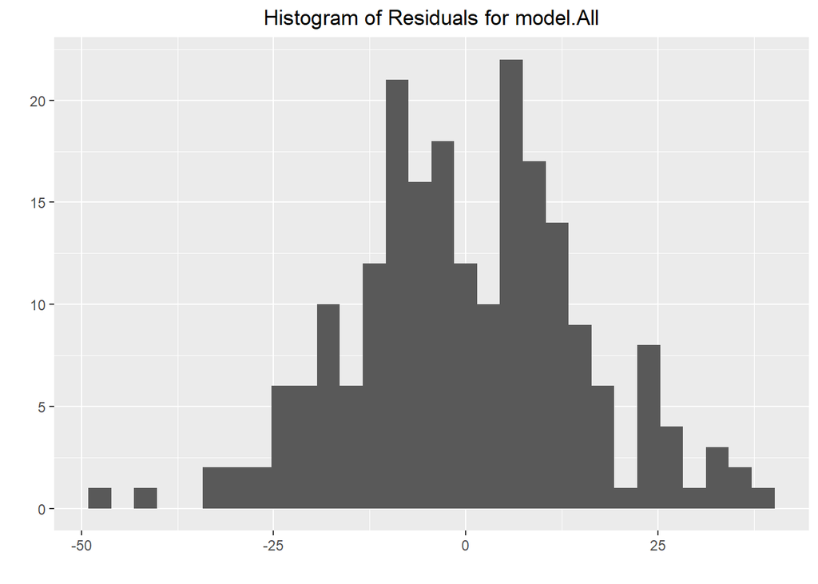

```r
# Plot location
setwd(figure_directory)

# Data to model
data_modified_ind <- ind_data %>%
  select(params$dependent_response_ind,
         params$dependent_response_DominateStrategy,
         Target,
         SessionOrder,
         Team,
         Player_ID)

# Generate models with variable response
GA_data_focus_ind <- data_modified_ind %>%
  filter(.data[[params$dependent_response_DominateStrategy]] == params$Strategy_GA_name_WithSpace)

model.All <- model_data_Target_Session(df = GA_data_focus_ind, dependent =  params$dependent_response_ind, model.type =  "All", is.team = FALSE, is.robust = FALSE)
# Histogram of Residuals - model.All
ggplot(model.All, aes(x = .resid)) +
  geom_histogram(bins = 30) +
  labs(title = paste("Histogram of Residuals for model.All"), x = "", y = "") +
  theme(plot.title = element_text(hjust = 0.5)) +
  ggsave(paste("Histogram_Residuals_", params$dependent_response_name_NoSpace, "_All_", params$Strategy_GA_name_NoSpace, "_Ind.png", sep =""))
```

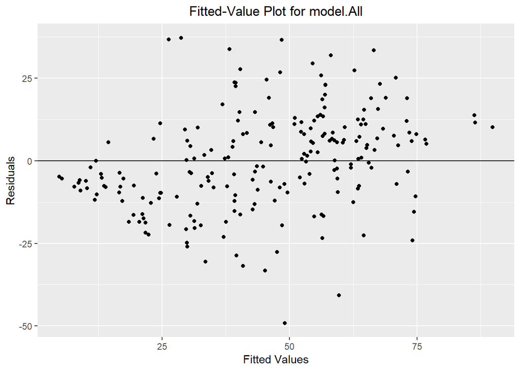

```r
# Fitted values - model.All
ggplot(model.All, aes(x = .fitted, y = .resid)) +
  geom_point() +
  geom_hline(yintercept = 0)+
  labs(title = paste("Fitted-Value Plot for model.All"), x = "Fitted Values", y = "Residuals") +
  theme(plot.title = element_text(hjust = 0.5)) +
  ggsave(paste("FittedValue_Residuals_", params$dependent_response_name_NoSpace, "_All_", params$Strategy_GA_name_NoSpace, "_Ind.png", sep =""))
```

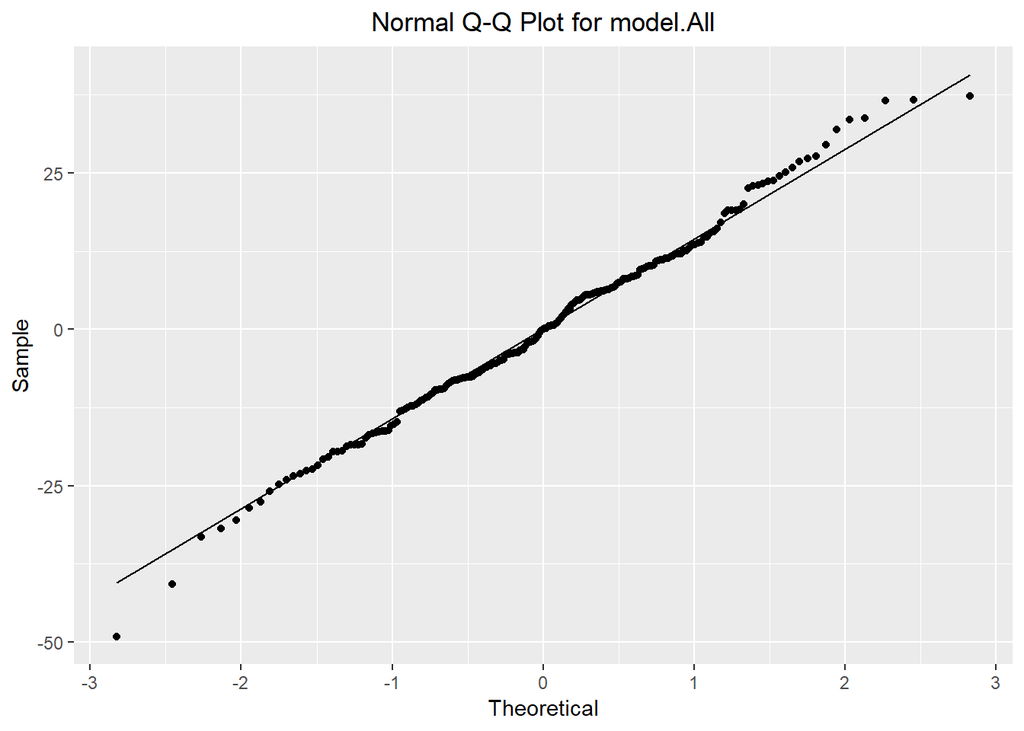

```r
# QQ plots - model.All
ggplot(model.All, aes(sample = .resid)) +
  stat_qq() +
  stat_qq_line()+
  labs(title = "Normal Q-Q Plot for model.All", x = "Theoretical", y = "Sample") +
   theme(plot.title = element_text(hjust = 0.5)) +
  ggsave(paste("QQ_Residuals_", params$dependent_response_name_NoSpace, "_All_", params$Strategy_GA_name_NoSpace, "_Ind.png", sep =""))
```

The plots indicate that no assumption is obviously violated. One could make the argument that there is a slight violation in the fitted value plot. I will compare the classic model to the robust model.

#### model.NoInteraction.NoTarget

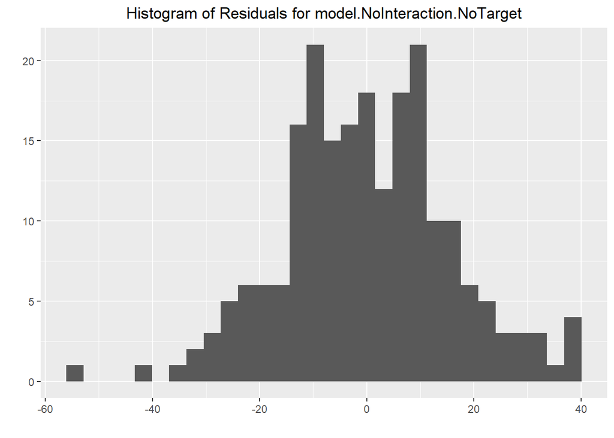

```r
# Plot location
setwd(figure_directory)

# Data to model
data_modified_ind <- ind_data %>%
  select(params$dependent_response_ind,
         params$dependent_response_DominateStrategy,
         Target,
         SessionOrder,
         Team,
         Player_ID)

# Generate models with variable response
GA_data_focus_ind <- data_modified_ind %>%
  filter(.data[[params$dependent_response_DominateStrategy]] == params$Strategy_GA_name_WithSpace)

model.NoInteraction.NoTarget <- model_data_Target_Session(df = GA_data_focus_ind, dependent =  params$dependent_response_ind, model.type =  "NoInteraction_NoTarget", is.team = FALSE, is.robust = FALSE)

# Histogram of Residuals - model.NoInteraction.NoTarget
ggplot(model.NoInteraction.NoTarget, aes(x = .resid)) +
  geom_histogram(bins = 30) +
  labs(title = paste("Histogram of Residuals for model.NoInteraction.NoTarget"), x = "", y = "") +
  theme(plot.title = element_text(hjust = 0.5)) +
  ggsave(paste("Histogram_Residuals_", params$dependent_response_name_NoSpace, "_NoInteractionNoTarget_", params$Strategy_GA_name_NoSpace, "_Ind.png", sep =""))
```

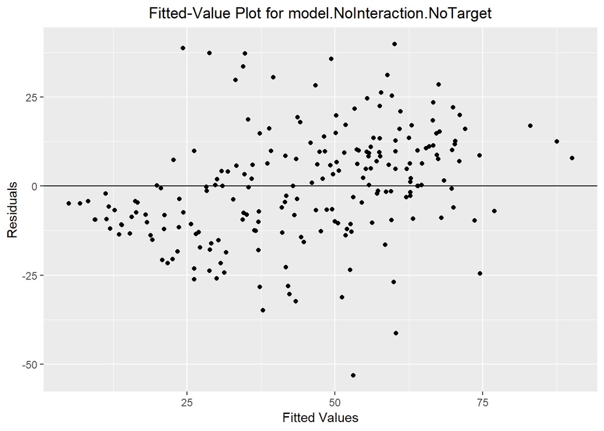

```r
# Fitted values - model.NoInteraction.NoTarget
ggplot(model.NoInteraction.NoTarget, aes(x = .fitted, y = .resid)) +
  geom_point() +
  geom_hline(yintercept = 0)+
  labs(title = paste("Fitted-Value Plot for model.NoInteraction.NoTarget"), x = "Fitted Values", y = "Residuals") +
  theme(plot.title = element_text(hjust = 0.5)) +
  ggsave(paste("FittedValue_Residuals_", params$dependent_response_name_NoSpace, "_NoInteractionNoTarget_", params$Strategy_GA_name_NoSpace, "_Ind.png", sep =""))
```

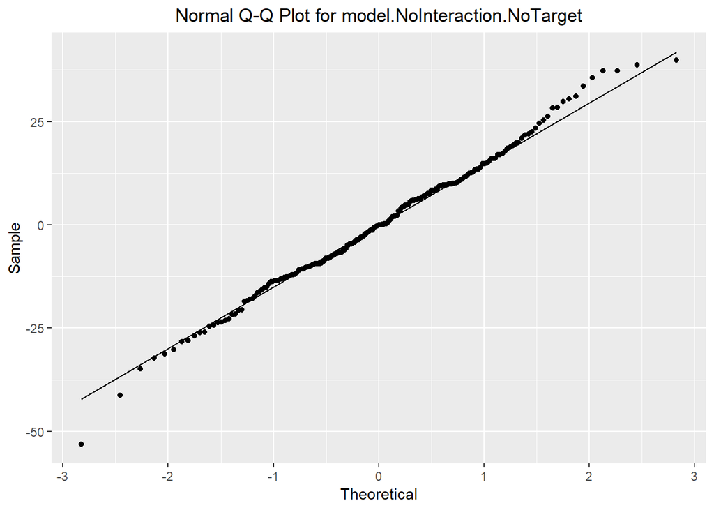

```r
# QQ plots - model.NoInteraction.NoTarget
ggplot(model.NoInteraction.NoTarget, aes(sample = .resid)) +
  stat_qq() +
  stat_qq_line()+
  labs(title = "Normal Q-Q Plot for model.NoInteraction.NoTarget", x = "Theoretical", y = "Sample") +
   theme(plot.title = element_text(hjust = 0.5)) +
  ggsave(paste("QQ_Residuals_", params$dependent_response_name_NoSpace, "_NoInteractionNoTarget_", params$Strategy_GA_name_NoSpace, "_Ind.png", sep =""))
```

It looks like there may be a slight violoation with assumption 2. I will need to compare the classic model to the robust model.

### model.NoInteraction

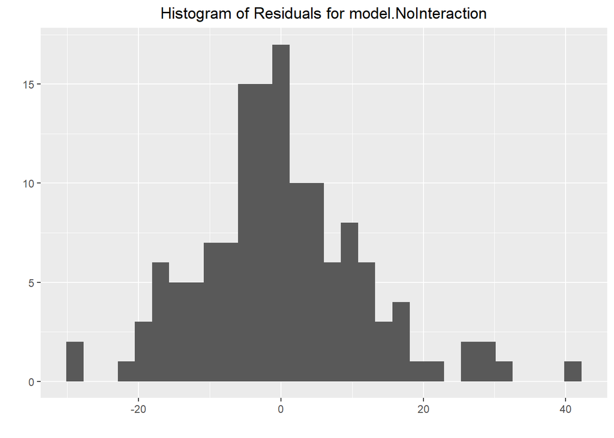

```r
# Plot location
setwd(figure_directory)

# Data to model
data_modified_ind <- ind_data %>%
  select(params$dependent_response_ind,
         params$dependent_response_DominateStrategy,
         Target,
         SessionOrder,
         Team,
         Player_ID)

# Generate models with variable response
GT_data_focus_ind <- data_modified_ind %>%
  filter(.data[[params$dependent_response_DominateStrategy]] == params$Strategy_GT_name_WithSpace)

model.NoInteraction <- model_data_Target_Session(df = GT_data_focus_ind, dependent =  params$dependent_response_ind, model.type =  "NoInteraction", is.team = FALSE, is.robust = FALSE)

# Histogram of Residuals - model.NoInteraction
ggplot(model.NoInteraction, aes(x = .resid)) +
  geom_histogram(bins = 30) +
  labs(title = paste("Histogram of Residuals for model.NoInteraction"), x = "", y = "") +
  theme(plot.title = element_text(hjust = 0.5)) +
  ggsave(paste("Histogram_Residuals_", params$dependent_response_name_NoSpace, "_NoInteraction_", params$Strategy_GT_name_NoSpace , "Ind.png", sep =""))
```

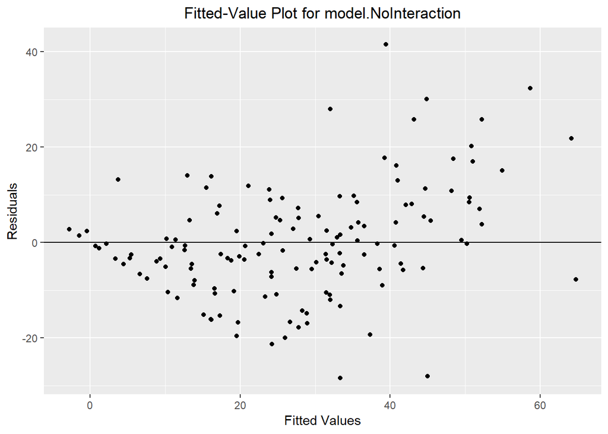

```r
# Fitted values - model.NoInteraction
ggplot(model.NoInteraction, aes(x = .fitted, y = .resid)) +
  geom_point() +
  geom_hline(yintercept = 0)+
  labs(title = paste("Fitted-Value Plot for model.NoInteraction"), x = "Fitted Values", y = "Residuals") +
  theme(plot.title = element_text(hjust = 0.5)) +
  ggsave(paste("FittedValue_Residuals_", params$dependent_response_name_NoSpace, "_NoInteraction_", params$Strategy_GT_name_NoSpace , "Ind.png", sep =""))
```

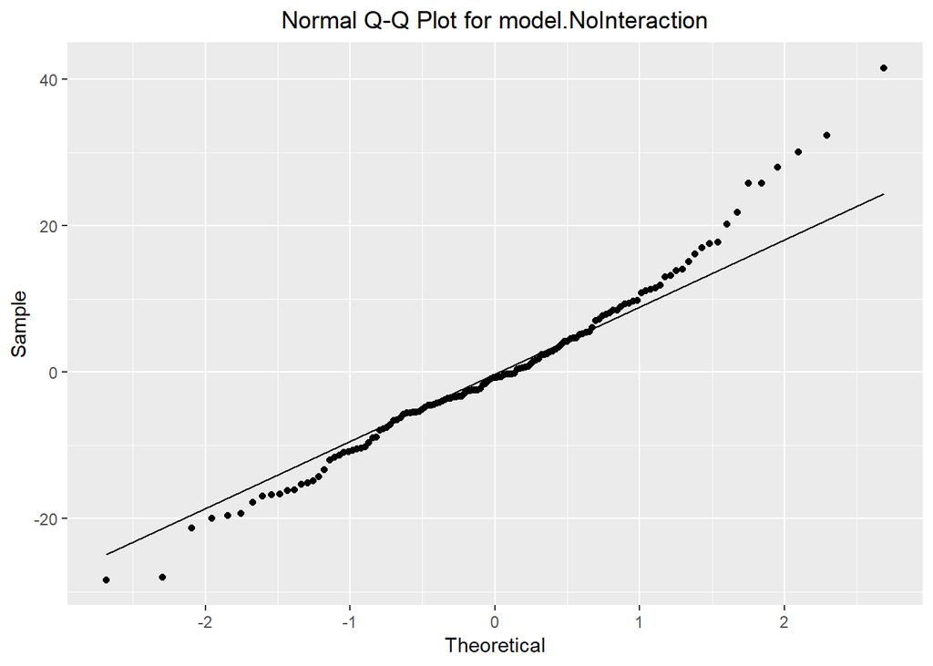

```r
# QQ plots - model.NoInteraction
ggplot(model.NoInteraction, aes(sample = .resid)) +
  stat_qq() +
  stat_qq_line()+
  labs(title = "Normal Q-Q Plot for model.NoInteraction", x = "Theoretical", y = "Sample") +
   theme(plot.title = element_text(hjust = 0.5)) +
  ggsave(paste("QQ_Residuals_", params$dependent_response_name_NoSpace, "_NoInteraction_", params$Strategy_GT_name_NoSpace , "Ind.png", sep =""))
```

It looks like assumption 2 and 3 are viloated. I need to compare the classic model with the robust model.

## Summary

Overall, I will need to compare the robust model to the classic model for model.All and model.NoInteraction.NoTarget for teams that use Go Alone. I will need to compare the robust model to the class model for model.NoInteraction for teams that use the Go Together method.

# Q: Does the violation influence the linear model estimation?

## Team

### GA

[No analysis was given]

### GT

[No analysis was given]

## Individual

### GA

#### model.All

```r
# Data to model
data_modified_ind <- ind_data %>%
  select(params$dependent_response_ind,
         params$dependent_response_DominateStrategy,
         Target,
         SessionOrder,
         Team,
         Player_ID)

# Generate models with variable response
GA_data_focus_ind <- data_modified_ind %>%
  filter(.data[[params$dependent_response_DominateStrategy]] == params$Strategy_GA_name_WithSpace)

model.All <- model_data_Target_Session(df = GA_data_focus_ind, dependent =  params$dependent_response_ind, model.type =  "All", is.team = FALSE, is.robust = FALSE)
rmodel.All <- model_data_Target_Session(df = GA_data_focus_ind, dependent =  params$dependent_response_ind, model.type =  "All", is.team = FALSE, is.robust = TRUE)
comparision_results <- compare(model.All, rmodel.All, show.rho.functions = FALSE)

comparision_results %>%
  kable(caption = "model.All") %>%
  kable_styling()
```

model.All

|  | model.All | rmodel.All |
| --- | --- | --- |
| Coef |  |  |
| (Intercept) | 55.55 ( 5.26) | 55.25 (5.02) |
| TargetInd_Team | -12.86 ( 6.51) | -12.83 (5.91) |
| TargetTeam | -11.05 ( 6.62) | -11.54 (6.04) |
| SessionOrder3 | -18.06 ( 6.50) | -16.86 (5.91) |
| SessionOrder4 | -13.05 ( 6.86) | -14.07 (6.22) |
| TargetInd_Team:SessionOrder3 | 28.27 (10.09) | 24.73 (9.18) |
| TargetTeam:SessionOrder3 | 19.62 ( 9.92) | 18.82 (9.07) |
| TargetInd_Team:SessionOrder4 | 8.45 (10.14) | 11.30 (9.23) |
| TargetTeam:SessionOrder4 | 7.98 ( 9.89) | 9.87 (8.99) |
| VarComp |  |  |
| (Intercept) \| Player_ID | 19.30 | 25.60 |
| (Intercept) \| Team | 8.72 | 0.00 |
| sigma | 18.2 | 15.8 |
| REML | 1906 |  |

I see no concerable difference. I will not transform.

#### model.NoInteraction.NoTarget

```r
# Data to model
data_modified_ind <- ind_data %>%
  select(params$dependent_response_ind,
         params$dependent_response_DominateStrategy,
         Target,
         SessionOrder,
         Team,
         Player_ID)

# Generate models with variable response
GA_data_focus_ind <- data_modified_ind %>%
  filter(.data[[params$dependent_response_DominateStrategy]] == params$Strategy_GA_name_WithSpace)

model.NoInteraction.NoTarget <- model_data_Target_Session(df = GA_data_focus_ind, dependent =  params$dependent_response_ind, model.type =  "NoInteraction_NoTarget", is.team = FALSE, is.robust = FALSE)
rmodel.NoInteraction.NoTarget <- model_data_Target_Session(df = GA_data_focus_ind, dependent =  params$dependent_response_ind, model.type =  "NoInteraction_NoTarget", is.team = FALSE, is.robust = TRUE)

comparision_results <- compare(model.NoInteraction.NoTarget, rmodel.NoInteraction.NoTarget, show.rho.functions = FALSE)

comparision_results %>%
  kable(caption = "model.NoInteraction.NoTarget") %>%
  kable_styling()
```

model.NoInteraction.NoTarget

|  | model.NoInteraction.NoTarget | rmodel.NoInteraction.NoTarget |
| --- | --- | --- |
| Coef |  |  |
| (Intercept) | 47.42 (3.33) | 47.02 (3.42) |
| SessionOrder3 | -2.57 (3.16) | -2.72 (2.73) |
| SessionOrder4 | -7.05 (3.21) | -6.49 (2.77) |
| VarComp |  |  |
| (Intercept) \| Player_ID | 19.16 | 25.46 |
| (Intercept) \| Team | 7.43 | 0.00 |
| sigma | 18.6 | 15.5 |
| REML | 1948 |  |

I see no concernable difference. I will not transform the data.

### GT

#### model.NoInteraction

```r
# Data to model
data_modified_ind <- ind_data %>%
  select(params$dependent_response_ind,
         params$dependent_response_DominateStrategy,
         Target,
         SessionOrder,
         Team,
         Player_ID)

# Generate models with variable response
GT_data_focus_ind <- data_modified_ind %>%
  filter(.data[[params$dependent_response_DominateStrategy]] == params$Strategy_GT_name_WithSpace)

model.NoInteraction <- model_data_Target_Session(df = GT_data_focus_ind, dependent =  params$dependent_response_ind, model.type =  "NoInteraction", is.team = FALSE, is.robust = FALSE)
rmodel.NoInteraction <- model_data_Target_Session(df = GT_data_focus_ind, dependent =  params$dependent_response_ind, model.type =  "NoInteraction", is.team = FALSE, is.robust = TRUE)

comparision_results <- compare(model.NoInteraction, rmodel.NoInteraction, show.rho.functions = FALSE)

comparision_results %>%
  kable(caption = "model.NoInteraction") %>%
  kable_styling()
```

model.NoInteraction

|  | model.NoInteraction | rmodel.NoInteraction |
| --- | --- | --- |
| Coef |  |  |
| (Intercept) | 39.88 (3.93) | 36.25 (3.45) |
| TargetInd_Team | -8.72 (3.09) | -5.17 (2.49) |
| TargetTeam | -11.03 (3.21) | -7.34 (2.60) |
| SessionOrder3 | -2.91 (3.26) | -2.42 (2.64) |
| SessionOrder4 | -7.86 (3.24) | -7.87 (2.62) |
| VarComp |  |  |
| (Intercept) \| Player_ID | 14.83 | 18.77 |
| (Intercept) \| Team | 8.05 | 0.00 |
| sigma | 14.2 | 11.2 |
| REML | 1179 |  |

I see no concernable difference. I will not transform the data

## Summary

Overall, none of the violations seem to have a noticable influence on the model when comepared to the robust model. I will not transform the data.

# Q: Are there any effects that are significant?

## Team

### GA

[No analysis was given]

### GT

[No analysis was given]

## Individual

### GA

#### model.All

```r
# Data to model
data_modified_ind <- ind_data %>%
  select(params$dependent_response_ind,
         params$dependent_response_DominateStrategy,
         Target,
         SessionOrder,
         Team,
         Player_ID)

# Generate models with variable response
GA_data_focus_ind <- data_modified_ind %>%
  filter(.data[[params$dependent_response_DominateStrategy]] == params$Strategy_GA_name_WithSpace)

model.All <- model_data_Target_Session(df = GA_data_focus_ind, dependent =  params$dependent_response_ind, model.type =  "All", is.team = FALSE, is.robust = FALSE)
summary(model.All)
```

```
## Linear mixed model fit by REML. t-tests use Satterthwaite's method [
## lmerModLmerTest]
## Formula:
## as.formula(paste(dependent, "~ Target * SessionOrder + (1|Team) + (1| Player_ID)"))
##    Data: df
##
## REML criterion at convergence: 1906.3
##
## Scaled residuals:
##      Min       1Q   Median       3Q      Max
## -2.69275 -0.52512 -0.00073  0.53774  2.04200
##
## Random effects:
##  Groups    Name        Variance Std.Dev.
##  Player_ID (Intercept) 372.64   19.304
##  Team      (Intercept)  76.11    8.724
##  Residual              332.31   18.229
## Number of obs: 213, groups:  Player_ID, 81; Team, 27
##
## Fixed effects:
##                              Estimate Std. Error      df t value Pr(>|t|)
## (Intercept)                    55.549      5.259  96.351  10.563  < 2e-16
## TargetInd_Team                -12.860      6.506 150.147  -1.977  0.04990
## TargetTeam                    -11.046      6.617 148.521  -1.669  0.09714
## SessionOrder3                 -18.061      6.499 150.147  -2.779  0.00615
## SessionOrder4                 -13.055      6.855 150.195  -1.904  0.05879
## TargetInd_Team:SessionOrder3   28.266     10.092 150.008   2.801  0.00577
## TargetTeam:SessionOrder3       19.622      9.923 148.006   1.977  0.04986
## TargetInd_Team:SessionOrder4    8.454     10.139 149.757   0.834  0.40574
## TargetTeam:SessionOrder4        7.979      9.891 150.179   0.807  0.42111
##
## (Intercept)                  ***
## TargetInd_Team               *
## TargetTeam                   .
## SessionOrder3                **
## SessionOrder4                .
## TargetInd_Team:SessionOrder3 **
## TargetTeam:SessionOrder3     *
## TargetInd_Team:SessionOrder4
## TargetTeam:SessionOrder4
## ---
## Signif. codes:  0 '***' 0.001 '**' 0.01 '*' 0.05 '.' 0.1 ' ' 1
##
## Correlation of Fixed Effects:
##             (Intr) TrgI_T TrgtTm SssnO3 SssnO4 TI_T:SO3 TT:SO3 TI_T:SO4
## TargtInd_Tm -0.662
## TargetTeam  -0.666  0.535
## SessinOrdr3 -0.666  0.645  0.611
## SessinOrdr4 -0.626  0.601  0.548  0.517
## TrgtI_T:SO3  0.466 -0.738 -0.364 -0.739 -0.351
## TrgtTm:SsO3  0.526 -0.436 -0.781 -0.766 -0.365  0.483
## TrgtI_T:SO4  0.499 -0.758 -0.380 -0.428 -0.792  0.472    0.267
## TrgtTm:SsO4  0.475 -0.359 -0.718 -0.351 -0.740  0.167    0.461  0.494
## convergence code: 0
## Model failed to converge with max|grad| = 0.00263007 (tol = 0.002, component 1)
```

**Note:** It is important to note that the model **failed to converge**. This means that the model was not able to be fitted. Any analysis from this model should not carry a lot of weight.

Inturpriting the main effects is made difficult when including the interaction effect.

```r
# Data to model
data_modified_ind <- ind_data %>%
  select(params$dependent_response_ind,
         params$dependent_response_DominateStrategy,
         Target,
         SessionOrder,
         Team,
         Player_ID)

# Generate models with variable response
GA_data_focus_ind <- data_modified_ind %>%
  filter(.data[[params$dependent_response_DominateStrategy]] == params$Strategy_GA_name_WithSpace)

model.All <- model_data_Target_Session(df = GA_data_focus_ind, dependent =  params$dependent_response_ind, model.type =  "All", is.team = FALSE, is.robust = FALSE)
emmeans(model.All, list(pairwise ~ Target), adjust = "tukey")
```

```
## NOTE: Results may be misleading due to involvement in interactions
```

```
## $`emmeans of Target`
##  Target   emmean   SE   df lower.CL upper.CL
##  Ind        45.2 3.53 43.2     38.0     52.3
##  Ind_Team   44.6 3.60 45.6     37.3     51.8
##  Team       43.3 3.53 43.2     36.2     50.4
##
## Results are averaged over the levels of: SessionOrder
## Degrees-of-freedom method: kenward-roger
## Confidence level used: 0.95
##
## $`pairwise differences of Target`
##  contrast        estimate   SE  df t.ratio p.value
##  Ind - Ind_Team     0.621 3.19 131 0.194   0.9794
##  Ind - Team         1.846 3.19 135 0.578   0.8319
##  Ind_Team - Team    1.225 3.18 130 0.385   0.9217
##
## Results are averaged over the levels of: SessionOrder
## P value adjustment: tukey method for comparing a family of 3 estimates
```

The result show no significant difference among the Target levels.

```r
# Data to model
data_modified_ind <- ind_data %>%
  select(params$dependent_response_ind,
         params$dependent_response_DominateStrategy,
         Target,
         SessionOrder,
         Team,
         Player_ID)

# Generate models with variable response
GA_data_focus_ind <- data_modified_ind %>%
  filter(.data[[params$dependent_response_DominateStrategy]] == params$Strategy_GA_name_WithSpace)

model.All <- model_data_Target_Session(df = GA_data_focus_ind, dependent =  params$dependent_response_ind, model.type =  "All", is.team = FALSE, is.robust = FALSE)
emmeans(model.All, list(pairwise ~ SessionOrder), adjust = "tukey")
```

```
## NOTE: Results may be misleading due to involvement in interactions
```

```
## $`emmeans of SessionOrder`
##  SessionOrder emmean   SE   df lower.CL upper.CL
##  2              47.6 3.43 40.1     40.6     54.5
##  3              45.5 3.60 45.6     38.2     52.7
##  4              40.0 3.63 46.3     32.7     47.3
##
## Results are averaged over the levels of: Target
## Degrees-of-freedom method: kenward-roger
## Confidence level used: 0.95
##
## $`pairwise differences of SessionOrder`
##  contrast estimate   SE  df t.ratio p.value
##  2 - 3        2.10 3.17 134 0.661   0.7865
##  2 - 4        7.58 3.20 135 2.370   0.0500
##  3 - 4        5.48 3.20 127 1.710   0.2056
##
## Results are averaged over the levels of: Target
## P value adjustment: tukey method for comparing a family of 3 estimates
```

```r
# Data to model
data_modified_ind <- ind_data %>%
  select(params$dependent_response_ind,
         params$dependent_response_DominateStrategy,
         Target,
         SessionOrder,
         Team,
         Player_ID)

# Generate models with variable response
GA_data_focus_ind <- data_modified_ind %>%
  filter(.data[[params$dependent_response_DominateStrategy]] == params$Strategy_GA_name_WithSpace)

model.All <- model_data_Target_Session(df = GA_data_focus_ind, dependent =  params$dependent_response_ind, model.type =  "All", is.team = FALSE, is.robust = FALSE)
emmeans(model.All, list(pairwise ~ Target | SessionOrder), adjust = "tukey")
```

```
## $`emmeans of Target | SessionOrder`
## SessionOrder = 2:
##  Target   emmean   SE    df lower.CL upper.CL
##  Ind        55.5 5.30  95.8     45.0     66.1
##  Ind_Team   42.7 5.00  93.0     32.8     52.6
##  Team       44.5 5.04  90.1     34.5     54.5
##
## SessionOrder = 3:
##  Target   emmean   SE    df lower.CL upper.CL
##  Ind        37.5 4.96  94.4     27.6     47.3
##  Ind_Team   52.9 5.82 119.1     41.4     64.4
##  Team       46.1 5.17 102.6     35.8     56.3
##
## SessionOrder = 4:
##  Target   emmean   SE    df lower.CL upper.CL
##  Ind        42.5 5.47 110.0     31.7     53.3
##  Ind_Team   38.1 5.13 104.3     27.9     48.3
##  Team       39.4 5.47 109.7     28.6     50.3
##
## Degrees-of-freedom method: kenward-roger
## Confidence level used: 0.95
##
## $`pairwise differences of Target | SessionOrder`
## SessionOrder = 2:
##  contrast        estimate   SE  df t.ratio p.value
##  Ind - Ind_Team     12.86 6.59 151  1.952  0.1279
##  Ind - Team         11.05 6.71 149  1.647  0.2294
##  Ind_Team - Team    -1.81 6.41 151 -0.283  0.9568
##
## SessionOrder = 3:
##  contrast        estimate   SE  df t.ratio p.value
##  Ind - Ind_Team    -15.41 6.95 149 -2.216  0.0717
##  Ind - Team         -8.58 6.37 149 -1.346  0.3719
##  Ind_Team - Team     6.83 7.08 149  0.965  0.6001
##
## SessionOrder = 4:
##  contrast        estimate   SE  df t.ratio p.value
##  Ind - Ind_Team      4.41 6.78 149  0.650  0.7929
##  Ind - Team          3.07 6.97 148  0.440  0.8987
##  Ind_Team - Team    -1.34 6.75 148 -0.198  0.9785
##
## P value adjustment: tukey method for comparing a family of 3 estimates
```

The result show no significant differences.

**Note:** Model failed to converge.

```r
# Data to model
data_modified_ind <- ind_data %>%
  select(params$dependent_response_ind,
         params$dependent_response_DominateStrategy,
         Target,
         SessionOrder,
         Team,
         Player_ID)

# Generate models with variable response
GA_data_focus_ind <- data_modified_ind %>%
  filter(.data[[params$dependent_response_DominateStrategy]] == params$Strategy_GA_name_WithSpace)

model.All <- model_data_Target_Session(df = GA_data_focus_ind, dependent =  params$dependent_response_ind, model.type =  "All", is.team = FALSE, is.robust = FALSE)
emmeans(model.All, list(pairwise ~ SessionOrder | Target), adjust = "tukey")
```

```
## $`emmeans of SessionOrder | Target`
## Target = Ind:
##  SessionOrder emmean   SE    df lower.CL upper.CL
##  2              55.5 5.30  95.8     45.0     66.1
##  3              37.5 4.96  94.4     27.6     47.3
##  4              42.5 5.47 110.0     31.7     53.3
##
## Target = Ind_Team:
##  SessionOrder emmean   SE    df lower.CL upper.CL
##  2              42.7 5.00  93.0     32.8     52.6
##  3              52.9 5.82 119.1     41.4     64.4
##  4              38.1 5.13 104.3     27.9     48.3
##
## Target = Team:
##  SessionOrder emmean   SE    df lower.CL upper.CL
##  2              44.5 5.04  90.1     34.5     54.5
##  3              46.1 5.17 102.6     35.8     56.3
##  4              39.4 5.47 109.7     28.6     50.3
##
## Degrees-of-freedom method: kenward-roger
## Confidence level used: 0.95
##
## $`pairwise differences of SessionOrder | Target`
## Target = Ind:
##  contrast estimate   SE  df t.ratio p.value
##  2 - 3       18.06 6.58 151  2.745  0.0185
##  2 - 4       13.05 6.94 151  1.882  0.1474
##  3 - 4       -5.01 6.64 149 -0.754  0.7317
##
## Target = Ind_Team:
##  contrast estimate   SE  df t.ratio p.value
##  2 - 3      -10.20 6.94 149 -1.470  0.3084
##  2 - 4        4.60 6.37 149  0.722  0.7506
##  3 - 4       14.81 7.09 149  2.089  0.0955
##
## Target = Team:
##  contrast estimate   SE  df t.ratio p.value
##  2 - 3       -1.56 6.56 151 -0.238  0.9692
##  2 - 4        5.08 6.75 151  0.752  0.7331
##  3 - 4        6.64 6.76 148  0.982  0.5895
##
## P value adjustment: tukey method for comparing a family of 3 estimates
```

**Note:** Model failed to converge.

#### model.NoInteraction.NoTarget

```r
# Data to model
data_modified_ind <- ind_data %>%
  select(params$dependent_response_ind,
         params$dependent_response_DominateStrategy,
         Target,
         SessionOrder,
         Team,
         Player_ID)

# Generate models with variable response
GA_data_focus_ind <- data_modified_ind %>%
  filter(.data[[params$dependent_response_DominateStrategy]] == params$Strategy_GA_name_WithSpace)

model.NoInteraction.NoTarget <- model_data_Target_Session(df = GA_data_focus_ind, dependent =  params$dependent_response_ind, model.type =  "NoInteraction_NoTarget", is.team = FALSE, is.robust = FALSE)

summary(model.NoInteraction.NoTarget)
```

```
## Linear mixed model fit by REML. t-tests use Satterthwaite's method [
## lmerModLmerTest]
## Formula:
## as.formula(paste(dependent, "~ SessionOrder + (1|Team) + (1| Player_ID)"))
##    Data: df
##
## REML criterion at convergence: 1947.8
##
## Scaled residuals:
##      Min       1Q   Median       3Q      Max
## -2.85519 -0.54977 -0.00134  0.52950  2.14588
##
## Random effects:
##  Groups    Name        Variance Std.Dev.
##  Player_ID (Intercept) 367.10   19.160
##  Team      (Intercept)  55.24    7.432
##  Residual              345.46   18.587
## Number of obs: 213, groups:  Player_ID, 81; Team, 27
##
## Fixed effects:
##               Estimate Std. Error      df t value Pr(>|t|)
## (Intercept)     47.425      3.327  45.238  14.254   <2e-16 ***
## SessionOrder3   -2.567      3.162 137.830  -0.812   0.4183
## SessionOrder4   -7.047      3.213 138.339  -2.193   0.0299 *
## ---
## Signif. codes:  0 '***' 0.001 '**' 0.01 '*' 0.05 '.' 0.1 ' ' 1
##
## Correlation of Fixed Effects:
##             (Intr) SssnO3
## SessinOrdr3 -0.429
## SessinOrdr4 -0.423  0.492
```

The restuls show a significant effect from session 4 in reference to session 2.

```r
# Data to model
data_modified_ind <- ind_data %>%
  select(params$dependent_response_ind,
         params$dependent_response_DominateStrategy,
         Target,
         SessionOrder,
         Team,
         Player_ID)

# Generate models with variable response
GA_data_focus_ind <- data_modified_ind %>%
  filter(.data[[params$dependent_response_DominateStrategy]] == params$Strategy_GA_name_WithSpace)

model.NoInteraction.NoTarget <- model_data_Target_Session(df = GA_data_focus_ind, dependent =  params$dependent_response_ind, model.type =  "NoInteraction_NoTarget", is.team = FALSE, is.robust = FALSE)

emmeans(model.NoInteraction.NoTarget, list(pairwise ~ SessionOrder), adjust = "tukey")
```

```
## $`emmeans of SessionOrder`
##  SessionOrder emmean   SE   df lower.CL upper.CL
##  2              47.4 3.33 44.5     40.7     54.1
##  3              44.9 3.47 49.6     37.9     51.8
##  4              40.4 3.52 51.6     33.3     47.4
##
## Degrees-of-freedom method: kenward-roger
## Confidence level used: 0.95
##
## $`pairwise differences of SessionOrder`
##  contrast estimate   SE  df t.ratio p.value
##  2 - 3        2.57 3.17 138 0.810   0.6974
##  2 - 4        7.05 3.22 138 2.189   0.0767
##  3 - 4        4.48 3.21 132 1.394   0.3471
##
## P value adjustment: tukey method for comparing a family of 3 estimates
```

Results showed no significant difference among the session orders. The results showed a **margnially significant** difference between session 2 and 4.

### GT

#### model.NoInteraction

```r
# Data to model
data_modified_ind <- ind_data %>%
  select(params$dependent_response_ind,
         params$dependent_response_DominateStrategy,
         Target,
         SessionOrder,
         Team,
         Player_ID)

# Generate models with variable response
GT_data_focus_ind <- data_modified_ind %>%
  filter(.data[[params$dependent_response_DominateStrategy]] == params$Strategy_GT_name_WithSpace)

model.NoInteraction <- model_data_Target_Session(df = GT_data_focus_ind, dependent =  params$dependent_response_ind, model.type =  "NoInteraction", is.team = FALSE, is.robust = FALSE)

summary(model.NoInteraction)
```

```
## Linear mixed model fit by REML. t-tests use Satterthwaite's method [
## lmerModLmerTest]
## Formula:
## as.formula(paste(dependent, "~ Target + SessionOrder + (1|Team) + (1| Player_ID)"))
##    Data: df
##
## REML criterion at convergence: 1178.6
##
## Scaled residuals:
##     Min      1Q  Median      3Q     Max
## -1.9954 -0.4523 -0.0508  0.4188  2.9271
##
## Random effects:
##  Groups    Name        Variance Std.Dev.
##  Player_ID (Intercept) 219.83   14.827
##  Team      (Intercept)  64.81    8.051
##  Residual              201.80   14.206
## Number of obs: 138, groups:  Player_ID, 54; Team, 18
##
## Fixed effects:
##                Estimate Std. Error      df t value Pr(>|t|)
## (Intercept)      39.882      3.931  37.237  10.145 2.88e-12 ***
## TargetInd_Team   -8.718      3.086  80.185  -2.825 0.005967 **
## TargetTeam      -11.026      3.207  84.483  -3.438 0.000911 ***
## SessionOrder3    -2.909      3.261  82.050  -0.892 0.375108
## SessionOrder4    -7.862      3.238  84.192  -2.429 0.017290 *
## ---
## Signif. codes:  0 '***' 0.001 '**' 0.01 '*' 0.05 '.' 0.1 ' ' 1
##
## Correlation of Fixed Effects:
##             (Intr) TrgI_T TrgtTm SssnO3
## TargtInd_Tm -0.306
## TargetTeam  -0.316  0.537
## SessinOrdr3 -0.380 -0.195 -0.151
## SessinOrdr4 -0.398 -0.159 -0.170  0.604
```

The results show a significant effect from Team and Ind_Team in reference to Ind condition. The results also show a significant effect from from session 4.

```r
# Data to model
data_modified_ind <- ind_data %>%
  select(params$dependent_response_ind,
         params$dependent_response_DominateStrategy,
         Target,
         SessionOrder,
         Team,
         Player_ID)

# Generate models with variable response
GT_data_focus_ind <- data_modified_ind %>%
  filter(.data[[params$dependent_response_DominateStrategy]] == params$Strategy_GT_name_WithSpace)

model.NoInteraction <- model_data_Target_Session(df = GT_data_focus_ind, dependent =  params$dependent_response_ind, model.type =  "NoInteraction", is.team = FALSE, is.robust = FALSE)

emmeans(model.NoInteraction, list(pairwise ~ Target), adjust = "tukey")
```

```
## $`emmeans of Target`
##  Target   emmean   SE   df lower.CL upper.CL
##  Ind        36.3 3.55 29.6     29.0     43.6
##  Ind_Team   27.6 3.51 28.6     20.4     34.8
##  Team       25.3 3.57 29.7     18.0     32.5
##
## Results are averaged over the levels of: SessionOrder
## Degrees-of-freedom method: kenward-roger
## Confidence level used: 0.95
##
## $`pairwise differences of Target`
##  contrast        estimate   SE   df t.ratio p.value
##  Ind - Ind_Team      8.72 3.09 83.3 2.819   0.0164
##  Ind - Team         11.03 3.22 87.1 3.421   0.0027
##  Ind_Team - Team     2.31 3.03 83.1 0.760   0.7282
##
## Results are averaged over the levels of: SessionOrder
## P value adjustment: tukey method for comparing a family of 3 estimates
```

The results show a **significant difference** between Ind and Ind_Team, and between Ind and Team.

```r
# Data to model
data_modified_ind <- ind_data %>%
  select(params$dependent_response_ind,
         params$dependent_response_DominateStrategy,
         Target,
         SessionOrder,
         Team,
         Player_ID)

# Generate models with variable response
GT_data_focus_ind <- data_modified_ind %>%
  filter(.data[[params$dependent_response_DominateStrategy]] == params$Strategy_GT_name_WithSpace)

model.NoInteraction <- model_data_Target_Session(df = GT_data_focus_ind, dependent =  params$dependent_response_ind, model.type =  "NoInteraction", is.team = FALSE, is.robust = FALSE)

emmeans(model.NoInteraction, list(pairwise ~ SessionOrder), adjust = "tukey")
```

```
## $`emmeans of SessionOrder`
##  SessionOrder emmean   SE   df lower.CL upper.CL
##  2              33.3 3.71 33.7     25.8     40.8
##  3              30.4 3.50 28.2     23.2     37.6
##  4              25.4 3.44 26.6     18.4     32.5
##
## Results are averaged over the levels of: Target
## Degrees-of-freedom method: kenward-roger
## Confidence level used: 0.95
##
## $`pairwise differences of SessionOrder`
##  contrast estimate   SE   df t.ratio p.value
##  2 - 3        2.91 3.27 85.0 0.889   0.6488
##  2 - 4        7.86 3.25 86.8 2.417   0.0462
##  3 - 4        4.95 2.89 81.8 1.711   0.2071
##
## Results are averaged over the levels of: Target
## P value adjustment: tukey method for comparing a family of 3 estimates
```

The results show a significant difference between session 2 and 4.

## Summary

Overall, at the individual level the results show a significant difference in self reported frustration when teams used Go Together. There was a **significant difference** between Ind and Ind_Team, and between Ind and Team. Specifically, the results suggested that when teams used Go Together, frustration was significantly reduced when teams were in the Team or Ind_Team condition, when compared to the Ind condition. There was a bigger reduction in frustration in the Team condition.

The results suggest that the Team and Ind_Team condition condition maay have reduced frustration.

# References

Field, A. P., & Wilcox, R. R. (2017). Robust statistical methods: A primer for clinical psychology and experimental psychopathology researchers. *Behaviour Research and Therapy*, *98*, 19–38. https://doi.org/10.1016/j.brat.2017.05.013

Galwey, N. W. (2014). Testing the assumptions of the analyses: Inspection of the residual values. In *Introduction to mixed modelling: Beyond regression and analysis of variance* (Second). Chichester, United Kingdom: John Wiley & Sons, Ltd.

Johnson, P. C. (2014). Extension of Nakagawa & Schielzeth’s R 2 GLMM to random slopes models. *Methods in Ecology and Evolution*, *5*(9), 944–946. https://doi.org/10.1111/2041-210X.12225

Nakagawa, S., & Schielzeth, H. (2013). A general and simple method for obtaining R 2 from generalized linear mixed-effects models. *Methods in Ecology and Evolution*, *4*(2), 133–142. https://doi.org/10.1111/j.2041-210x.2012.00261.x

Tukey, J. W. (1977). *Exploratory data analysis*. Reading, Mass.: Addison-Wesley Pub.